# Self-reported Acceptability

Kendra Wyant

2021-07-15

**Purpose: This file is the primary analysis script for the self-report acceptability data (acceptability.csv). This includes all figures, tables, and statistical analyses.**

### Setup

Paths  
*NOTE: Change path to location of acceptability.csv file*

```r
path_data <- "P:/studydata/risk/data_processed/burden"
```

Packages and Source

```r
library(tidyverse)
library(kableExtra)
library(broom)
library(lme4)
library(ggtext)
library(car)
library(corx)
library(patchwork)
library(psych)

options(knitr.kable.NA = '')
```

Functions

```r
# Adds Y label to histogram plots with 2 rows - code adapted from Stack overflow
add_global_label <- function(pwobj, Xlab = NULL, Ylab = NULL, Xgap = 0.03, Ygap = 0.03, ...) {
  ylabgrob <- patchwork::plot_spacer()
  if (!is.null(Ylab)) {
    ylabgrob <- ggplot() +
      geom_text(aes(x = 1, y = 1), label = Ylab, angle = 90, size = 4) +
      theme_void()
  }
  if (!is.null(Ylab) & is.null(Xlab)) {
    return((ylabgrob + patchworkGrob(pwobj)) +
             patchwork::plot_layout(widths = 100 * c(Ygap, 1 - Ygap)))
  }

  return(pwobj)
}
```

### Read in data

```r
data <- read_csv(file.path(path_data, "acceptability.csv"), col_types = cols()) %>%
  # wristband will be analyzed in supplemental - not enough observations
  select(-contains("wristband"))
```

Pull out last observation for each participant

```r
# pull out last available sleep monitor data since this date will be earlier than last
# survey date for some due to discontinuation of monitor
data_sleep <- data %>%
  filter(!is.na(sleep_interfere)) %>%
  group_by(subid) %>%
  arrange(desc(date)) %>%
  slice(1) %>%
  ungroup() %>%
  select(c(subid, starts_with("sleep_")))

# pull out most recent survey for each subid
data_last <- data %>%
  select(-c(starts_with("sleep_"))) %>%
  group_by(subid) %>%
  arrange(desc(date)) %>%
  slice(1) %>%
  ungroup() %>%
  # join with sleep data
  full_join(data_sleep, by = c("subid")) %>%
  glimpse()
```

```
## Rows: 154
## Columns: 28
## $ subid                    <dbl> 1, 2, 3, 5, 6, 7, 9, 10, 11, 15, 16, 18, 1...
## $ response_id              <chr> "R_3pb42s0hzoIFsk9", "R_1rvLRa6XSAGssBO", ...
## $ date                     <date> 2017-06-05, 2017-06-16, 2017-06-21, 2017-...
## $ daily_survey_interfere   <dbl> 1, 1, 1, 1, 1, 2, 0, 2, 2, 1, 1, 1, 1, 1, ...
## $ daily_survey_dislike     <dbl> 1, 1, 2, 1, 1, 2, 1, 2, 0, 1, 1, 1, 0, 2, ...
## $ daily_survey_4_1year     <dbl> 1, -2, 2, 1, 1, 2, -1, 2, -1, 1, -1, 1, 0,...
## $ daily_survey_1_1year     <dbl> 1, -2, 2, 1, 2, 2, 0, 2, -2, 1, 1, 2, 2, 2...
## $ daily_survey_text        <chr> "The home surveys were easy to complete bu...
## $ audio_checkin_interfere  <dbl> 1, 2, 1, 1, 1, 2, 1, 2, 2, -1, 1, -2, -1, ...
## $ audio_checkin_dislike    <dbl> 1, 2, 2, 1, 1, 2, 1, 2, 0, -1, 1, -2, -2, ...
## $ audio_checkin_1year      <dbl> 1, 2, 2, 1, 1, 2, 1, 2, -2, -1, 1, -2, -2,...
## $ audio_checkin_text       <chr> "I enjoyed the daily check more than all t...
## $ carrying_phone_interfere <dbl> 1, 2, 2, 2, 2, 2, 1, 2, 2, 2, 2, 2, 2, 2, ...
## $ carrying_phone_dislike   <dbl> 1, 2, 2, 2, 2, 2, 1, 2, 2, 2, 2, 2, 2, 2, ...
## $ carrying_phone_1year     <dbl> 1, 2, 2, 2, 2, 2, 1, 2, -2, 2, 2, 2, 2, 2,...
## $ carrying_phone_text      <chr> "The i-phone is a great resource to use. H...
## $ location_dislike         <dbl> 1, 1, 2, -1, 1, 2, 1, 2, 1, 1, 1, 0, 2, 2,...
## $ location_1year           <dbl> 1, 2, 2, 1, 2, 2, 0, 2, -2, 1, 1, -1, 2, 2...
## $ location_text            <chr> "Not an issue.", "This didn't change where...
## $ sms_content_dislike      <dbl> 1, 1, 2, -1, 1, 2, 0, 2, 0, 1, -1, -2, 2, ...
## $ sms_content_1year        <dbl> 1, 2, 1, 1, 2, 2, 0, 2, -2, 1, -1, 0, 1, 2...
## $ phone_text               <chr> "I did not use the texting options and pre...
## $ all_logs_dislike         <dbl> 0, 1, 2, 1, 1, 2, 0, 2, 0, 1, 0, 0, 2, 2, ...
## $ all_logs_1year           <dbl> 1, 2, 1, 1, 2, 2, 0, 2, -2, 1, 0, 1, 2, 2,...
## $ sleep_interfere          <dbl> 1, 2, 2, 1, 1, 2, -2, 2, 0, 2, 2, 2, 2, 2,...
## $ sleep_dislike            <dbl> 1, 2, 2, 1, -1, 2, 2, 2, -1, 2, 1, 2, 2, 2...
## $ sleep_1year              <dbl> 1, -2, 2, 1, 1, 2, -1, 2, -2, -2, 1, 2, 2,...
## $ sleep_text               <chr> "There were problems with the sleep monito...
```

### Interference

#### Histogram plot

The plot below is Figure 2 from the manuscript. It shows the distribution of participant responses to the self-reported acceptability item about interference. Responses are grouped by personal sensing data stream and the amount of active effort required to collect it.

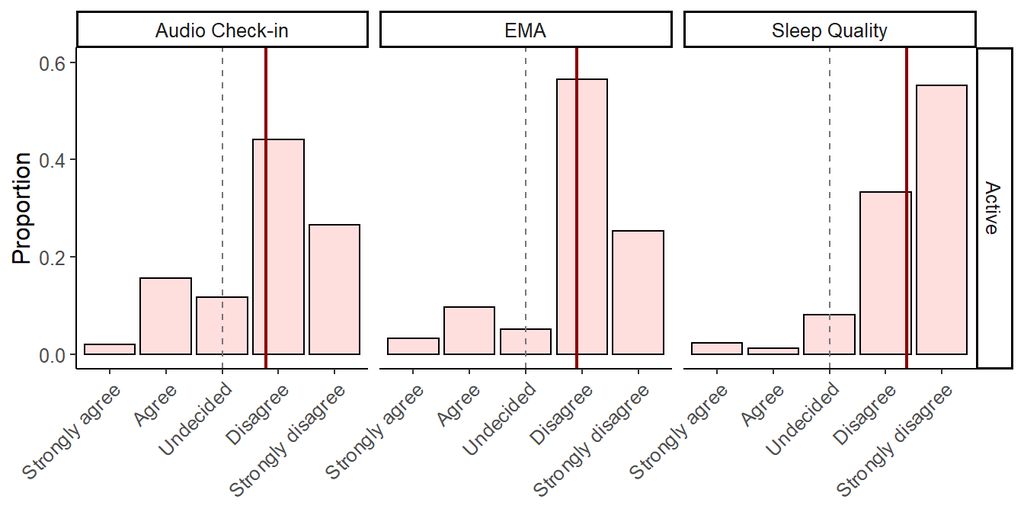

```r
interference_plot_data <- data_last %>%
  select(contains("interfere"), -carrying_phone_interfere) %>%
  pivot_longer(everything(), "measure", values_drop_na = TRUE) %>%
  mutate(measure = factor(measure,
                          levels = c("audio_checkin_interfere", "daily_survey_interfere",
                                     "sleep_interfere"),
                          labels = c("Audio Check-in", "EMA", "Sleep Quality"))) %>%
  mutate(value = factor(value, levels = c(-2:2), labels = c("Strongly agree", "Agree", "Undecided", "Disagree", "Strongly disagree"))) %>%
  mutate(active = case_when(measure == "Audio Check-in" ~ "Active",
                            measure == "EMA" ~ "Active",
                            measure == "Sleep Quality" ~ "Active"))

interference_plot <- interference_plot_data %>%
  filter(measure == "Audio Check-in" | measure == "EMA" | measure == "Sleep Quality") %>%
  ggplot(aes(x = value, y = ..prop.., group = measure)) +
  geom_bar(color = "black", fill = "#FFDEDE") +
  facet_grid(active ~ measure) +
  theme_classic() +
  labs(y = "Proportion",
       x = NULL) +
  theme(legend.position = "none",
        text = element_text(size = 12),
        axis.text.x = element_text(angle = 45, hjust = 1)) +
  ylim(0, .6) +
  geom_vline(aes(xintercept = "Undecided"), linetype = "dashed", size = .4, color = "#787575") +
  geom_vline(aes(xintercept = means), interference_plot_data %>%
  filter(measure == "Audio Check-in" | measure == "EMA" | measure == "Sleep Quality") %>%
  group_by(measure) %>%
  summarise(means = mean(as.numeric(value), na.rm = TRUE)), size = .705, color = "dark red")


interference_plot
```

Uncomment to save figure  
*Note: Replace PATH with location to save plot.*

```r
# ggsave(plot = interference_plot,  "PATH", width = 7.75, height = 3.5, units = "in", device = "png",  dpi = 500)
```

#### Correlation and Summary Statistics

Run one sample t-tests to compare each raw data stream mean (for self-reported acceptability about interference) to a neutral acceptability score of 0.

```r
int_sleep <- tidy(lm(sleep_interfere ~ 1, data = data_last)) %>%
  mutate(sd = sd(data_last$sleep_interfere, na.rm = TRUE),
         d = mean(data_last$sleep_interfere, na.rm = TRUE)/sd)
int_audio <- tidy(lm(audio_checkin_interfere ~ 1, data = data_last)) %>%
  mutate(sd = sd(data_last$audio_checkin_interfere, na.rm = TRUE),
         d = mean(data_last$audio_checkin_interfere, na.rm = TRUE)/sd)
int_ema <- tidy(lm(daily_survey_interfere ~ 1, data = data_last)) %>%
  mutate(sd = sd(data_last$daily_survey_interfere, na.rm = TRUE),
         d = mean(data_last$daily_survey_interfere, na.rm = TRUE)/sd)
```

This table is Table 4 from the manuscript. It reports the summary statistics for each one sample t-test and pairwise correlations between personal sensing data streams. One sample t-tests revealed that each mean interference score was significantly more acceptable than 0.

```r
corrplot_int <- data_last %>%
  select(`Audio Check-in` = audio_checkin_interfere,
         `EMA` = daily_survey_interfere,
         `Sleep Quality` = sleep_interfere) %>%
  corx(triangle = "lower",
       stars = c(0.05),
       method = "pearson",
       describe = c(`$M$` = mean, `$SD$` = sd))

corrplot_int <- as_tibble(corrplot_int, rownames = " ")
corrplot_int[corrplot_int == " - " ] <- "--"

corrplot_int <- corrplot_int %>%
  mutate(`$N$` = c(154, 154, 87)) %>%
  mutate(`$t$` = c(str_c(round(int_audio$statistic, 2), "*"),
                   str_c(round(int_ema$statistic, 2), "*"),
                   str_c(round(int_sleep$statistic, 2), "*"))) %>%
  mutate(`$d$` = (c(round(int_audio$d, 2), round(int_ema$d, 2), round(int_sleep$d, 2)))) %>%
  select(` `, `1`, `2`, `$N$`, `$M$`, `$SD$`, everything())

corrplot_int %>%
  kbl(align = c("l", "c", "c", "c", "c", "c", "c", "c")) %>%
  kable_classic(html_font = "Arial") %>%
  row_spec(c(1:3), background = "#FFDEDE") %>%
  pack_rows("Active", 1, 3, background = "#FFDEDE") %>%
  footnote("* p < 0.05")
```

1

2

$N$

$M$

$SD$

$t$

$d$

**Active**

1. Audio Check-in

–

154

0.78

1.07

9.05*

0.73

2. EMA

.42*

–

154

0.91

0.99

11.37*

0.92

3. Sleep Quality

-.06

.24*

87

1.38

0.87

14.86*

1.59

Note:

* p < 0.05

#### ICC

Additionally, an ICC (type 3) showed that, on average, interference ratings were moderately consistent across the data streams, ICC = .42, 95% CI = [.31 - .53].

```r
data_last %>%
  select(`EMA` = daily_survey_interfere,
         `Audio check-in` = audio_checkin_interfere) %>%
  ICC()
```

```
## Call: ICC(x = .)
##
## Intraclass correlation coefficients
##                          type  ICC   F df1 df2       p lower bound upper bound
## Single_raters_absolute   ICC1 0.42 2.5 153 154 2.3e-08        0.31        0.52
## Single_random_raters     ICC2 0.42 2.5 153 153 2.0e-08        0.31        0.52
## Single_fixed_raters      ICC3 0.42 2.5 153 153 2.0e-08        0.31        0.53
## Average_raters_absolute ICC1k 0.59 2.5 153 154 2.3e-08        0.47        0.69
## Average_random_raters   ICC2k 0.59 2.5 153 153 2.0e-08        0.47        0.69
## Average_fixed_raters    ICC3k 0.60 2.5 153 153 2.0e-08        0.47        0.69
##
##  Number of subjects = 154     Number of Judges =  2
```

### Dislike

#### Histogram Plot

The plot below is Figure 3 from the manuscript. It shows the distribution of participant responses to the self-reported acceptability item about dislike Responses are grouped by personal sensing data stream and the amount of active effort required to collect it.

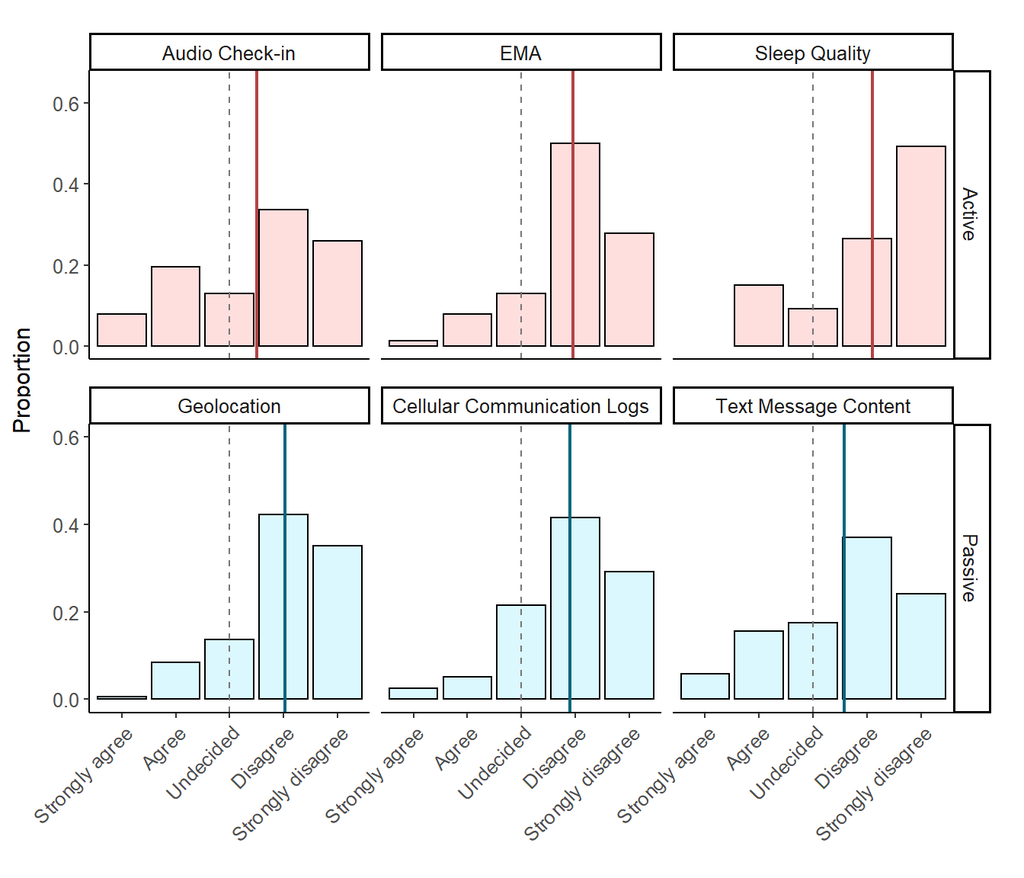

```r
dislike_plot_data <- data_last %>%
  select(contains("dislike")) %>%
  pivot_longer(everything(), "measure", values_drop_na = TRUE) %>%
   mutate(measure = factor(measure,
                          levels = c("audio_checkin_dislike", "daily_survey_dislike", "sleep_dislike",
                                     "location_dislike", "all_logs_dislike", "sms_content_dislike"),
                          labels = c("Audio Check-in", "EMA", "Sleep Quality",
                                     "Geolocation", "Cellular Communication Logs", "Text Message Content"))) %>%
  mutate(value = factor(value, levels = c(-2:2), labels = c("Strongly agree", "Agree", "Undecided", "Disagree", "Strongly disagree"))) %>%
  mutate(active = case_when(measure == "Audio Check-in" ~ "Active",
                            measure == "EMA" ~ "Active",
                            measure == "Sleep Quality" ~ "Active",
                            measure == "Geolocation" ~ "Passive",
                            measure == "Cellular Communication Logs" ~ "Passive",
                            measure == "Text Message Content" ~ "Passive"))

active_dis <- dislike_plot_data %>%
  filter(measure == "Audio Check-in" | measure == "EMA" | measure == "Sleep Quality") %>%
  ggplot(aes(x = value, y = ..prop.., group = measure)) +
  geom_bar(color = "black", fill = "#FFDEDE") +
  facet_grid(active ~ measure) +
  theme_classic() +
  labs(y = NULL,
       x = NULL) +
  theme(legend.position = "none",
        axis.text.x=element_blank(),
        axis.ticks.x=element_blank(),
        text = element_text(size = 12)) +
  ylim(0, .65) +
  geom_vline(aes(xintercept = means), dislike_plot_data %>%
  filter(measure == "Audio Check-in" | measure == "EMA" | measure == "Sleep Quality") %>%
  group_by(measure) %>%
  summarise(means = mean(as.numeric(value), na.rm = TRUE)), size = .705, color = "#b44343") +
  geom_vline(aes(xintercept = "Undecided"), linetype = "dashed", size = .4, color = "#787575") +
  theme(text = element_text(size = 12))


passive_dis <- dislike_plot_data %>%
  filter(measure == "Geolocation" | measure == "Cellular Communication Logs" | measure == "Text Message Content") %>%
  ggplot(aes(x = value, y = ..prop.., group = measure)) +
  geom_bar(color = "black", fill = "#DBF8FF") +
  facet_grid(active ~ measure) +
  theme_classic() +
  labs(y = NULL,
       x = NULL) +
    theme(legend.position = "none",
        text = element_text(size = 12),
        axis.text.x = element_text(angle = 45, hjust = 1)) +
  ylim(0, .6) +
  geom_vline(aes(xintercept = means), dislike_plot_data %>%
  filter(measure == "Geolocation" | measure == "Cellular Communication Logs" | measure == "Text Message Content") %>%
  group_by(measure) %>%
  summarise(means = mean(as.numeric(value), na.rm = TRUE)), size = .705, color = "#05667b") +
  geom_vline(aes(xintercept = "Undecided"), linetype = "dashed", size = .4, color = "#787575")

dislike_plot <- wrap_plots(active_dis, passive_dis, ncol = 1)

dislike_plot <- dislike_plot  %>%
  add_global_label(Ylab = "                   Proportion",
                   Ygap = .02
)

dislike_plot
```

Uncomment to save figure  
*Note: Replace PATH with location to save plot.*

```r
# ggsave(plot = dislike_plot,  "PATH", width = 7.75, height = 6, units = "in", device = "png",  dpi = 500)
```

#### Correlation and Summary Statistics

Run one sample t-tests to compare each raw data stream mean (for self-reported acceptability about dislike) to a neutral acceptability score of 0.

```r
dis_sleep <- tidy(lm(sleep_dislike ~ 1, data = data_last)) %>%
  mutate(sd = sd(data_last$sleep_dislike, na.rm = TRUE),
         d = mean(data_last$sleep_dislike, na.rm = TRUE)/sd)
dis_audio <- tidy(lm(audio_checkin_dislike ~ 1, data = data_last)) %>%
  mutate(sd = sd(data_last$audio_checkin_dislike, na.rm = TRUE),
         d = mean(data_last$audio_checkin_dislike, na.rm = TRUE)/sd)
dis_ema <- tidy(lm(daily_survey_dislike ~ 1, data = data_last)) %>%
  mutate(sd = sd(data_last$daily_survey_dislike, na.rm = TRUE),
         d = mean(data_last$daily_survey_dislike, na.rm = TRUE)/sd)
dis_geolocation <- tidy(lm(location_dislike ~ 1, data = data_last)) %>%
  mutate(sd = sd(data_last$location_dislike, na.rm = TRUE),
         d = mean(data_last$location_dislike, na.rm = TRUE)/sd)
dis_logs <- tidy(lm(all_logs_dislike ~ 1, data = data_last)) %>%
  mutate(sd = sd(data_last$all_logs_dislike, na.rm = TRUE),
         d = mean(data_last$all_logs_dislike, na.rm = TRUE)/sd)
dis_text_content <- tidy(lm(sms_content_dislike ~ 1, data = data_last)) %>%
  mutate(sd = sd(data_last$sms_content_dislike, na.rm = TRUE),
         d = mean(data_last$sms_content_dislike, na.rm = TRUE)/sd)
```

This table is Table 5 from the manuscript. It reports the summary statistics for each one sample t-test and pairwise correlations between personal sensing data streams. One sample t-tests revealed that each mean dislike score was significantly more acceptable than 0.

```r
corrplot_dis <- data_last %>%
  select(`Audio Check-in` = audio_checkin_dislike,
         `EMA` = daily_survey_dislike,
         `Sleep Quality` = sleep_dislike,
         `Geolocation` = location_dislike,
         `Cellular Communication Logs` = all_logs_dislike,
         `Text Message Content` = sms_content_dislike) %>%
  corx(triangle = "lower",
       stars = c(0.05),
       method = "pearson",
       describe = c(`$M$` = mean, `$SD$` = sd))

corrplot_dis <- as_tibble(corrplot_dis, rownames = " ")
corrplot_dis[corrplot_dis== " - " ] <- "--"

corrplot_dis <- corrplot_dis %>%
  mutate(`$N$` = c(154, 154, 87, 154, 154, 154)) %>%
  mutate(`$t$` = c(str_c(round(dis_audio$statistic, 2), "*"),
                   str_c(round(dis_ema$statistic, 2), "*"),
                   str_c(round(dis_sleep$statistic, 2), "*"),
                   str_c(round(dis_geolocation$statistic, 2), "*"),
                   str_c(round(dis_logs$statistic, 2), "*"),
                   str_c(round(dis_text_content$statistic, 2), "*"))) %>%
  mutate(`$d$` = (c(round(dis_audio$d, 2), round(dis_ema$d, 2), round(dis_sleep$d, 2),
                    round(dis_geolocation$d, 2), round(dis_logs$d, 2), round(dis_text_content$d, 2)))) %>%
  select(` `, `1`, `2`, `3`, `4`, `5`, `$N$`, `$M$`, `$SD$`, everything())

corrplot_dis %>%
  kbl(align = c("l", "c", "c", "c", "c", "c", "c", "c", "c", "c", "c")) %>%
  kable_classic(html_font = "Arial") %>%
  pack_rows("Active", 1, 3, background = "#FFDEDE") %>%
  pack_rows("Passive", 4, 6, background = "#DBF8FF") %>%
  row_spec(c(1:3), background = "#FFDEDE") %>%
  row_spec(c(4:6), background = "#DBF8FF") %>%
  footnote("* p < 0.05")
```

1

2

3

4

5

$N$

$M$

$SD$

$t$

$d$

**Active**

1. Audio Check-in

–

154

0.51

1.28

4.91*

0.40

2. EMA

.57*

–

154

0.95

0.92

12.92*

1.04

3. Sleep Quality

.25*

.26*

–

87

1.10

1.09

9.45*

1.01

**Passive**

4. Geolocation

.31*

.36*

.41*

–

154

1.03

0.94

13.51*

1.09

5. Cellular Communication Logs

.22*

.25*

.33*

.67*

–

154

0.90

0.97

11.45*

0.92

6. Text Message Content

.34*

.28*

.19

.62*

.69*

154

0.58

1.18

6.07*

0.49

Note:

* p < 0.05

#### ICC

An ICC (type 3) showed that, on average, the dislike ratings were moderately consistent across the data streams, ICC = .42, 95% CI = [.35 - .48].

```r
data_last %>%
  select(`EMA` = daily_survey_dislike,
         `Audio check-in` = audio_checkin_dislike,
         `Geolocation` = location_dislike,
         `Cellular communication logs` = all_logs_dislike,
         `Text message content` = sms_content_dislike) %>%
  ICC()
```

```
## Call: ICC(x = .)
##
## Intraclass correlation coefficients
##                          type  ICC   F df1 df2       p lower bound upper bound
## Single_raters_absolute   ICC1 0.39 4.2 153 616 1.7e-37        0.33        0.46
## Single_random_raters     ICC2 0.40 4.6 153 612 2.2e-41        0.33        0.47
## Single_fixed_raters      ICC3 0.42 4.6 153 612 2.2e-41        0.35        0.48
## Average_raters_absolute ICC1k 0.76 4.2 153 616 1.7e-37        0.71        0.81
## Average_random_raters   ICC2k 0.77 4.6 153 612 2.2e-41        0.71        0.81
## Average_fixed_raters    ICC3k 0.78 4.6 153 612 2.2e-41        0.73        0.82
##
##  Number of subjects = 154     Number of Judges =  5
```

### Willingness to Continue for One Year

#### Histogram Plot

The plot below is Figure 5 from the manuscript. It shows the distribution of participant responses to the self-reported acceptability item about willingness to continue for one year. Responses are grouped by personal sensing data stream and the amount of active effort required to collect it.

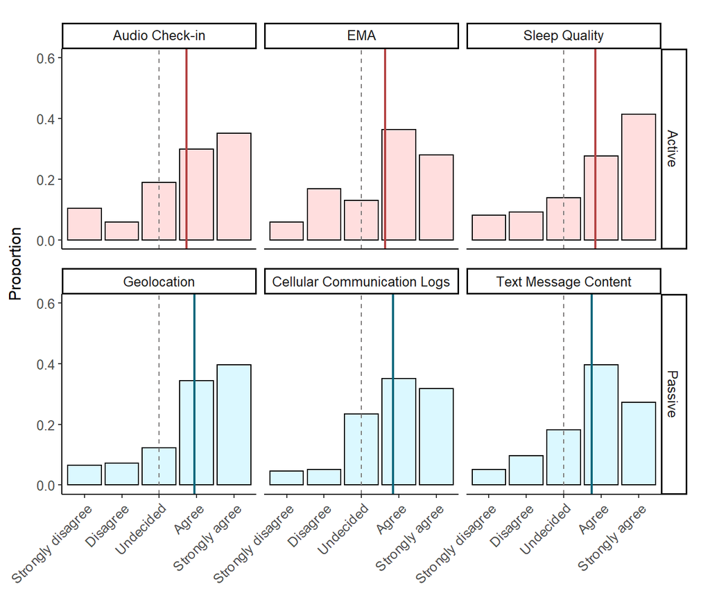

```r
willingness_plot_data <- data_last %>%
  select(contains("1year")) %>%
  pivot_longer(everything(), "measure", values_drop_na = TRUE) %>%
  mutate(measure = factor(measure,
                          levels = c("audio_checkin_1year", "daily_survey_4_1year",
                                     "daily_survey_1_1year", "sleep_1year", "location_1year",
                                     "all_logs_1year", "sms_content_1year"),
                          labels = c("Audio Check-in", "EMA", "Daily Survey (x1)<i><sup>a</sup></i>",
                                     "Sleep Quality", "Geolocation", "Cellular Communication Logs",
                                     "Text Message Content"))) %>%
  mutate(value = factor(value, levels = c(-2:2), labels = c("Strongly disagree", "Disagree", "Undecided", "Agree", "Strongly agree"))) %>%
  mutate(active = case_when(measure == "Audio Check-in" ~ "Active",
                            measure == "EMA" ~ "Active",
                            measure == "Sleep Quality" ~ "Active",
                            measure == "Geolocation" ~ "Passive",
                            measure == "Cellular Communication Logs" ~ "Passive",
                            measure == "Text Message Content" ~ "Passive"))

willingness_active <- willingness_plot_data %>%
  filter(measure == "Audio Check-in" | measure == "EMA" | measure == "Sleep Quality") %>%
  ggplot(aes(x = value, y = ..prop.., group = measure)) +
  geom_bar(color = "black", fill = "#FFDEDE") +
  facet_grid(active ~ measure) +
  theme_classic() +
  labs(y = NULL,
       x = NULL) +
  theme(legend.position = "none",
        axis.text.x=element_blank(),
        axis.ticks.x=element_blank(),
        text = element_text(size = 12),
        strip.text = element_markdown()) +
  ylim(0, .6) +
  geom_vline(aes(xintercept = means), willingness_plot_data %>%
  filter(measure == "Audio Check-in" | measure == "EMA" | measure == "Sleep Quality") %>%
  group_by(measure) %>%
  summarise(means = mean(as.numeric(value), na.rm = TRUE)), size = .705, color = "#b44343") +
  geom_vline(aes(xintercept = "Undecided"), linetype = "dashed", size = .4, color = "#787575")


willingness_passive <- willingness_plot_data %>%
  filter(measure == "Geolocation" | measure == "Cellular Communication Logs" | measure == "Text Message Content") %>%
  ggplot(aes(x = value, y = ..prop.., group = measure)) +
  geom_bar(color = "black", fill = "#DBF8FF") +
  facet_grid(active ~ measure) +
  theme_classic() +
  labs(y = NULL,
       x = NULL) +
    theme(legend.position = "none",
        text = element_text(size = 12),
        axis.text.x = element_text(angle = 45, hjust = 1)) +
  ylim(0, .6) +
  geom_vline(aes(xintercept = means), willingness_plot_data %>%
  filter(measure == "Geolocation" | measure == "Cellular Communication Logs" | measure == "Text Message Content") %>%
  group_by(measure) %>%
  summarise(means = mean(as.numeric(value), na.rm = TRUE)), size = .705, color = "#05667b") +
  geom_vline(aes(xintercept = "Undecided"), linetype = "dashed", size = .4, color = "#787575")

willingness_final_plot <- wrap_plots(willingness_active, willingness_passive, ncol = 1)

willingness_final_plot <- willingness_final_plot  %>%
  add_global_label(Ylab = "                   Proportion",
                   Ygap = .02
)

willingness_final_plot
```

Uncomment to save figure  
*Note: Replace PATH with location to save plot.*

```r
# ggsave(plot = willingness_final_plot,  "PATH", width = 7.75, height = 6, units = "in", device = "png",  dpi = 500)
```

#### Correlation and Summary Statistics

Run one sample t-tests to compare each raw data stream mean (for self-reported acceptability about willingness to continue for one year) to a neutral acceptability score of 0.

```r
use_audio <- tidy(lm(audio_checkin_1year ~ 1, data = data_last)) %>%
  mutate(sd = sd(data_last$audio_checkin_1year, na.rm = TRUE),
         d = mean(data_last$audio_checkin_1year, na.rm = TRUE)/sd)
use_sleep <- tidy(lm(sleep_1year ~ 1, data = data_last)) %>%
  mutate(sd = sd(data_last$sleep_1year, na.rm = TRUE),
         d = mean(data_last$sleep_1year, na.rm = TRUE)/sd)
use_ema <- tidy(lm(daily_survey_4_1year ~ 1, data = data_last)) %>%
  mutate(sd = sd(data_last$daily_survey_4_1year, na.rm = TRUE),
         d = mean(data_last$daily_survey_4_1year, na.rm = TRUE)/sd)
use_geolocation <- tidy(lm(location_1year ~ 1, data = data_last)) %>%
  mutate(sd = sd(data_last$location_1year, na.rm = TRUE),
         d = mean(data_last$location_1year, na.rm = TRUE)/sd)
use_logs <- tidy(lm(all_logs_1year ~ 1, data = data_last)) %>%
  mutate(sd = sd(data_last$all_logs_1year, na.rm = TRUE),
         d = mean(data_last$all_logs_1year, na.rm = TRUE)/sd)
use_text_content <- tidy(lm(sms_content_1year ~ 1, data = data_last)) %>%
  mutate(sd = sd(data_last$sms_content_1year, na.rm = TRUE),
         d = mean(data_last$sms_content_1year, na.rm = TRUE)/sd)
```

This table is Table 6 from the manuscript. It reports the summary statistics for each one sample t-test and pairwise correlations between personal sensing data streams. One sample t-tests revealed that each mean willingness score was significantly more acceptable than 0.

```r
corrplot_will <- data_last %>%
  select(`Audio Check-in` = audio_checkin_1year,
         `EMA` = daily_survey_4_1year,
         `Sleep Quality` = sleep_1year,
         `Geolocation` = location_1year,
         `Cellular Communication Logs` = all_logs_1year,
         `Text Message Content` = sms_content_1year) %>%
  corx(triangle = "lower",
       stars = c(0.05),
       method = "pearson",
       describe = c(`$M$` = mean, `$SD$` = sd))

corrplot_will <- as_tibble(corrplot_will, rownames = " ")
corrplot_will[corrplot_will== " - " ] <- "--"

corrplot_will <- corrplot_will %>%
  mutate(`$N$` = c(154, 154, 87, 154, 154, 154)) %>%
  mutate(`$t$` = c(str_c(round(use_audio$statistic, 2), "*"),
                   str_c(round(use_ema$statistic, 2), "*"),
                   str_c(round(use_sleep$statistic, 2), "*"),
                   str_c(round(use_geolocation$statistic, 2), "*"),
                   str_c(round(use_logs$statistic, 2), "*"),
                   str_c(round(use_text_content$statistic, 2), "*"))) %>%
  mutate(`$d$` = (c(round(use_audio$d, 2), round(use_ema$d, 2), round(use_sleep$d, 2),
                    round(use_geolocation$d, 2), round(use_logs$d, 2), round(use_text_content$d, 2)))) %>%
  select(` `, `1`, `2`, `3`, `4`, `5`, `$N$`, `$M$`, `$SD$`, everything())

corrplot_will %>%
  kbl(align = c("l", "c", "c", "c", "c", "c", "c", "c", "c", "c")) %>%
  kable_classic(html_font = "Arial") %>%
  pack_rows("Active", 1, 3, background = "#FFDEDE") %>%
  pack_rows("Passive", 4, 6, background = "#DBF8FF") %>%
  row_spec(c(1:3), background = "#FFDEDE") %>%
  row_spec(c(4:6), background = "#DBF8FF") %>%
  footnote("* p < 0.05")
```

1

2

3

4

5

$N$

$M$

$SD$

$t$

$d$

**Active**

1. Audio Check-in

–

154

0.73

1.28

7.09*

0.57

2. EMA

.44*

–

154

0.64

1.22

6.47*

0.52

3. Sleep Quality

.44*

.41*

–

87

0.85

1.28

6.19*

0.66

**Passive**

4. Geolocation

.51*

.48*

.53*

–

154

0.94

1.18

9.83*

0.79

5. Cellular Communication Logs

.47*

.47*

.47*

.65*

–

154

0.84

1.07

9.76*

0.79

6. Text Message Content

.47*

.39*

.37*

.60*

.84*

154

0.74

1.12

8.21*

0.66

Note:

* p < 0.05

#### ICC

An ICC (type 3) showed that, on average, the willingness ratings were moderately consistent across the data streams, ICC = .52, 95% CI = [.46 - .58].

```r
data_last %>%
  select(`EMA` = daily_survey_4_1year,
         `Audio check-in` = audio_checkin_1year,
         `Geolocation` = location_1year,
         `Cellular communication logs` = all_logs_1year,
         `Text message content` = sms_content_1year) %>%
  ICC()
```

```
## Call: ICC(x = .)
##
## Intraclass correlation coefficients
##                          type  ICC   F df1 df2       p lower bound upper bound
## Single_raters_absolute   ICC1 0.52 6.4 153 616 2.2e-62        0.46        0.58
## Single_random_raters     ICC2 0.52 6.5 153 612 4.0e-63        0.46        0.58
## Single_fixed_raters      ICC3 0.52 6.5 153 612 4.0e-63        0.46        0.58
## Average_raters_absolute ICC1k 0.84 6.4 153 616 2.2e-62        0.81        0.87
## Average_random_raters   ICC2k 0.84 6.5 153 612 4.0e-63        0.81        0.87
## Average_fixed_raters    ICC3k 0.85 6.5 153 612 4.0e-63        0.81        0.88
##
##  Number of subjects = 154     Number of Judges =  5
```

### Effect of Active Effort on Dislike and Willingness to Continue for One Year

#### Create dataframes

- active = audio check in and daily survey
- passive = location, sms content, logs

NOTE: Sleep monitor is an active measure but due to sample size is not included in analyses. Carrying phone is not included as personal sensing signal. Daily survey (x 1) is hypothetical and only included in supplemental.

Dislike - Active and Passive Means and group difference

```r
data_dislike <- data_last %>%
  # get subject level means for active and passive measures
  group_by(subid) %>%
  summarise(Active = mean(c(daily_survey_dislike, audio_checkin_dislike), na.rm = TRUE),
            Passive = mean(c(location_dislike, all_logs_dislike, sms_content_dislike), na.rm = TRUE),
            dislike_diff = Passive - Active)
data_dislike %>%
  print(n = Inf)
```

```
## # A tibble: 154 x 4
##     subid Active Passive dislike_diff
##   * <dbl>  <dbl>   <dbl>        <dbl>
##   1     1    1     0.667       -0.333
##   2     2    1.5   1           -0.5
##   3     3    2     2            0
##   4     5    1    -0.333       -1.33
##   5     6    1     1            0
##   6     7    2     2            0
##   7     9    1     0.333       -0.667
##   8    10    2     2            0
##   9    11    0     0.333        0.333
##  10    15    0     1            1
##  11    16    1     0           -1
##  12    18   -0.5  -0.667       -0.167
```

[output cut: 142 more lines]

Willingness to continue - Active and Passive Means and group difference

```r
data_willingness <- data_last %>%
  # get subject level means for active and passive measures
  group_by(subid) %>%
  summarise(Active = mean(c(daily_survey_4_1year, audio_checkin_1year), na.rm = TRUE),
            Passive = mean(c(location_1year, all_logs_1year, sms_content_1year), na.rm = TRUE),
            willingness_diff = Passive - Active)
data_willingness %>%
  print(n = Inf)
```

```
## # A tibble: 154 x 4
##     subid Active Passive willingness_diff
##   * <dbl>  <dbl>   <dbl>            <dbl>
##   1     1    1     1                0
##   2     2    0     2                2
##   3     3    2     1.33            -0.667
##   4     5    1     1                0
##   5     6    1     2                1
##   6     7    2     2                0
##   7     9    0     0                0
##   8    10    2     2                0
##   9    11   -1.5  -2               -0.5
##  10    15    0     1                1
##  11    16    0     0                0
##  12    18   -0.5   0                0.5
```

[output cut: 142 more lines]

#### Paired Samples t-tests

*Intercept = mean difference between active and passive group*

**Dislike**

```r
model_dislike <- lm(dislike_diff ~ 1, data = data_dislike)
summary(model_dislike)
```

```
##
## Call:
## lm(formula = dislike_diff ~ 1, data = data_dislike)
##
## Residuals:
##     Min      1Q  Median      3Q     Max
## -4.1028 -0.4361 -0.1028  0.5639  2.8972
##
## Coefficients:
##             Estimate Std. Error t value Pr(>|t|)
## (Intercept)  0.10281    0.08503   1.209    0.228
##
## Residual standard error: 1.055 on 153 degrees of freedom
```

Participants did not different significantly in their dislike of active vs. passive methods, t(153) = 1.21, p = 0.23.

Formula for Cohens D for paired samples t-test:  
d = mean(passive) - mean(active)/ sd(difference) = 0.1

**Willingness**

```r
model_willingness <- lm(willingness_diff ~ 1, data = data_willingness)
summary(model_willingness)
```

```
##
## Call:
## lm(formula = willingness_diff ~ 1, data = data_willingness)
##
## Residuals:
##     Min      1Q  Median      3Q     Max
## -2.3214 -0.3214 -0.1548  0.3452  3.3452
##
## Coefficients:
##             Estimate Std. Error t value Pr(>|t|)
## (Intercept)  0.15476    0.07292   2.122   0.0354 *
## ---
## Signif. codes:  0 '***' 0.001 '**' 0.01 '*' 0.05 '.' 0.1 ' ' 1
##
## Residual standard error: 0.9049 on 153 degrees of freedom
```

Participants reported higher acceptability with respect to willingness for passive data streams (M = 0.84, SD = 1) relative to active data streams (M = 0.69, SD = 1.06), t(153) = 2.12, p = 0.04.

d = 0.17

#### Histograms

**Dislike**

```r
# transform dataframe of active/passive means to long
data_dislike_long <- data_dislike %>%
  pivot_longer(cols = c(Active, Passive), names_to = "effort", values_to = "dislike") %>%
  select(-dislike_diff)
```

The figure below is Figure 4 from the manuscript. It shows the distribution of average dislike scores grouped by active and passive methods.

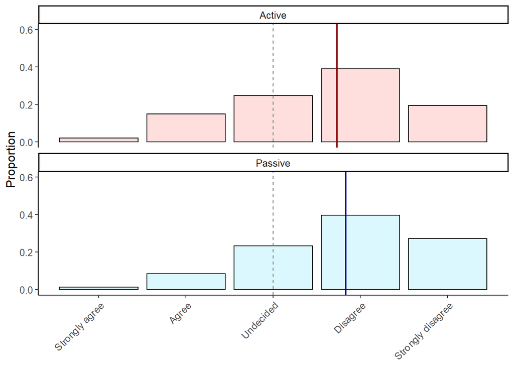

```r
dislike_avg_hist <- data_dislike_long %>%
  # bin continuous means, keep numeric
  mutate(dislike_binned = as.numeric(cut(dislike, breaks = c(-2.5, -1.5, -0.5, 0.5, 1.5, 2.5)))) %>%
  # change 1 to 5 scale to -2 to 2
  mutate(dislike_binned = dislike_binned - 3) %>%
  ggplot(aes(x = dislike_binned, y = ..prop.., group = effort, fill = effort)) +
  geom_bar(color = "black") +
  facet_wrap(~ effort, ncol = 1) +
  theme_classic() +
  labs(y = "Proportion",
       x = NULL) +
    theme(legend.position = "none",
        text = element_text(size = 12),
        axis.text.x = element_text(angle = 45, hjust = 1)) +
  ylim(0, .6) +
  scale_x_continuous(breaks = c(-2, -1, 0, 1, 2),
                   labels = c("Strongly agree", "Agree", "Undecided", "Disagree", "Strongly disagree")) +
  scale_fill_manual(values = c("#FFDEDE", "#DBF8FF")) +
  geom_vline(aes(xintercept = m), data_dislike_long %>%
               group_by(effort) %>%
               summarise(m = mean(dislike)), size = .705, color = c("dark red", "dark blue")) +
  geom_vline(aes(xintercept = 0), linetype = "dashed", size = .4, color = "#787575")

dislike_avg_hist
```

**Willingness**

```r
# transform dataframe of active/passive means to long
data_willingness_long <- data_willingness %>%
  pivot_longer(cols = c(Active, Passive), names_to = "effort", values_to = "willingness") %>%
  select(-willingness_diff)
```

The figure below is Figure 6 from the manuscript. It shows the distribution of average willingness scores grouped by active and passive methods.

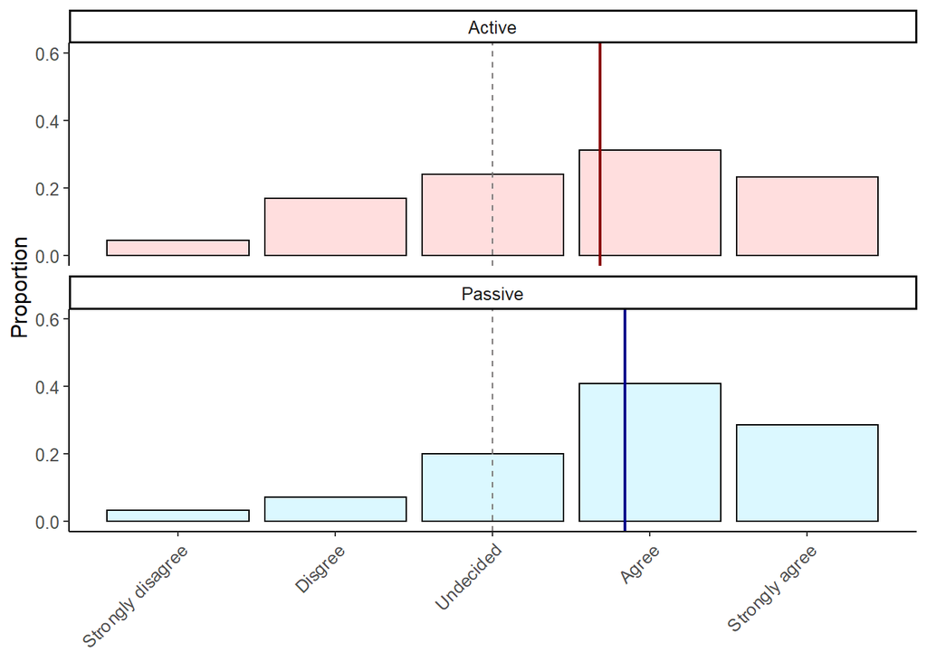

```r
willingness_avg_hist <- data_willingness_long %>%
  # bin continuous means, keep numeric
  mutate(willingness_binned = as.numeric(cut(willingness, breaks = c(-2.5, -1.5, -0.5, 0.5, 1.5, 2.5)))) %>%
  # change 1 to 5 scale to -2 to 2
  mutate(willingness_binned = willingness_binned - 3) %>%
  ggplot(aes(x = willingness_binned, y = ..prop.., group = effort, fill = effort)) +
  geom_bar(color = "black") +
  facet_wrap(~ effort, ncol = 1) +
  theme_classic() +
  labs(y = "Proportion",
       x = NULL) +
    theme(legend.position = "none",
        text = element_text(size = 12),
        axis.text.x = element_text(angle = 45, hjust = 1)) +
  ylim(0, .6) +
  scale_x_continuous(breaks = c(-2, -1, 0, 1, 2),
                   labels = c("Strongly disagree", "Disgree", "Undecided", "Agree", "Strongly agree")) +
  scale_fill_manual(values = c("#FFDEDE", "#DBF8FF")) +
  geom_vline(aes(xintercept = m), data_willingness_long %>%
               group_by(effort) %>%
               summarise(m = mean(willingness)), size = .705, color = c("dark red", "dark blue")) +
  geom_vline(aes(xintercept = 0), linetype = "dashed", size = .4, color = "#787575")

willingness_avg_hist
```

Uncomment to save figures  
*Note: Replace PATH with location for saved plots*

```r
# ggsave(plot = dislike_avg_hist,  "PATH", width = 5, height = 5.5, units = "in", device = "png",  dpi = 500)
# ggsave(plot = willingness_avg_hist,  "PATH", width = 5, height = 5.5, units = "in", device = "png",  dpi = 500)
```